# 5 Análisis exploratorio

Autor/a

Mario Camacho

Fecha de publicación

11 mayo 2026

**NotaEscala LATCH y test de Matthew**

La escala de evaluación de LATCH y el test de Matthew solo están recogidos en los casos nacidos durante 2022 (hay menos de 100 registros en años previos).

Por este motivo:

- La cohorte para el análisis de infecciones (nacimientos 2018–2021) no incluye estas variables.
- Para el análisis de la escala de evaluación LATCH y el test de Matthew se usará únicamente los nacidos en 2022.
- El éxito de la lactancia en relación a estas dos variables se medirá a través de la duración de la lactancia materna.

**AdvertenciaDuda**

¿APGAR tiene sentido como categóricas? Las medianas e IQR por grupo son muy similares, a lo mejor tiene sentido ver la distribución de la escala categórica.

## 5.1 Table1

**Descripción de la base de datos de pacientes.**

Año de nacimiento.

```
 2018  2019  2020  2021 2022*
12259 11809 10855 10869 10914
```

**Descripción de los casos hospitalizados nacidos desde enero de 2018 hasta diciembre de 2021.**

Los valores con NA en tipo de lactancia no están incluidos en el análisis estratificado, por lo que los totales pueden no coincidir con los conteos globales.

| **Variable** | **Overall** N = 1,584<sup>1</sup> | **Tipo de lactancia** **Materna** N = 867<sup>1</sup> | **Tipo de lactancia** **Artificial** N = 421<sup>1</sup> | **Tipo de lactancia** **Mixta** N = 296<sup>1</sup> | **p-value**<sup>2</sup> |  |
| --- | --- | --- | --- | --- | --- | --- |
| Año de nacimiento |  |  |  |  |  | 0.4 |
| 2018 | 620 (39%) | 337 (39%) | 174 (41%) | 109 (37%) |  |  |
| 2019 | 430 (27%) | 249 (29%) | 107 (25%) | 74 (25%) |  |  |
| 2020 | 142 (9.0%) | 79 (9.1%) | 37 (8.8%) | 26 (8.8%) |  |  |
| 2021 | 392 (25%) | 202 (23%) | 103 (24%) | 87 (29%) |  |  |
| Sexo |  |  |  |  | 0.3 |  |
| Hombre | 921 (58%) | 493 (57%) | 245 (58%) | 183 (62%) |  |  |
| Mujer | 663 (42%) | 374 (43%) | 176 (42%) | 113 (38%) |  |  |
| Peso al nacimiento | 3,200 [2,848, 3,500] | 3,230 [2,905, 3,520] | 3,150 [2,760, 3,460] | 3,138 [2,678, 3,500] | <0.001 |  |
| Edad de la madre | 32 [27, 36] | 33 [28, 36] | 32 [27, 36] | 33 [27, 36] | 0.4 |  |
| Unknown | 61 | 43 | 12 | 6 |  |  |
| Control |  |  |  |  | 0.6 |  |
| No | 20 (1.4%) | 9 (1.1%) | 6 (1.5%) | 5 (1.8%) |  |  |
| Sí | 1,446 (99%) | 792 (99%) | 385 (98%) | 269 (98%) |  |  |
| Unknown | 118 | 66 | 30 | 22 |  |  |
| Educación maternal al parto |  |  |  |  | 0.002 |  |
| No | 275 (23%) | 128 (19%) | 91 (29%) | 56 (26%) |  |  |
| Sí | 912 (77%) | 530 (81%) | 220 (71%) | 162 (74%) |  |  |
| Unknown | 397 | 209 | 110 | 78 |  |  |
| Lugar del parto |  |  |  |  | 0.2 |  |
| Clínica Privada | 74 (4.7%) | 48 (5.5%) | 14 (3.3%) | 12 (4.1%) |  |  |
| Domicilio | 1 (<0.1%) | 1 (0.1%) | 0 (0%) | 0 (0%) |  |  |
| Extranjero | 1 (<0.1%) | 1 (0.1%) | 0 (0%) | 0 (0%) |  |  |
| Hospital Público | 1,498 (95%) | 815 (94%) | 404 (96%) | 279 (95%) |  |  |
| Otras CC.AA | 5 (0.3%) | 1 (0.1%) | 1 (0.2%) | 3 (1.0%) |  |  |
| Unknown | 5 | 1 | 2 | 2 |  |  |
| APGAR 1 minuto | 9.00 [9.00, 9.00] | 9.00 [9.00, 9.00] | 9.00 [9.00, 9.00] | 9.00 [8.00, 9.00] | 0.004 |  |
| Unknown | 257 | 144 | 67 | 46 |  |  |
| APGAR 5 minutos | 10.00 [10.00, 10.00] | 10.00 [10.00, 10.00] | 10.00 [10.00, 10.00] | 10.00 [9.00, 10.00] | 0.010 |  |
| Unknown | 334 | 185 | 88 | 61 |  |  |
| Edad gestacional | 39.00 [38.00, 40.00] | 39.00 [38.00, 40.00] | 39.00 [38.00, 40.00] | 39.00 [37.00, 40.00] | <0.001 |  |
| Duración lactancia materna (meses) | 4 [1, 8] | 6 [3, 12] | 0 [0, 0] | 3 [1, 5] | <0.001 |  |
| Unknown | 1,104 | 566 | 359 | 179 |  |  |
| Fórmulas especiales |  |  |  |  | 0.017 |  |
| No | 147 (69%) | 87 (77%) | 37 (57%) | 23 (64%) |  |  |
| Sí | 67 (31%) | 26 (23%) | 28 (43%) | 13 (36%) |  |  |
| Unknown | 1,370 | 754 | 356 | 260 |  |  |
| Año de ingreso |  |  |  |  | 0.2 |  |
| 2018 | 330 (21%) | 177 (20%) | 97 (23%) | 56 (19%) |  |  |
| 2019 | 560 (35%) | 311 (36%) | 150 (36%) | 99 (33%) |  |  |
| 2020 | 225 (14%) | 129 (15%) | 55 (13%) | 41 (14%) |  |  |
| 2021 | 355 (22%) | 200 (23%) | 86 (20%) | 69 (23%) |  |  |
| 2022 | 114 (7.2%) | 50 (5.8%) | 33 (7.8%) | 31 (10%) |  |  |
| Días en la UCI | 4.1 [2.7, 7.7] | 4.1 [2.7, 8.2] | 3.2 [1.9, 7.5] | 5.0 [3.6, 8.1] | 0.5 |  |
| Unknown | 1,529 | 835 | 409 | 285 |  |  |
| Severidad |  |  |  |  |  |  |
| 1 | 1,196 (76%) | 646 (75%) | 323 (77%) | 227 (77%) |  |  |
| 2 | 287 (18%) | 160 (18%) | 81 (19%) | 46 (16%) |  |  |
| 3 | 96 (6.1%) | 59 (6.8%) | 16 (3.8%) | 21 (7.1%) |  |  |
| 4 | 5 (0.3%) | 2 (0.2%) | 1 (0.2%) | 2 (0.7%) |  |  |
| enf_inf_int | 113 (7.1%) | 59 (6.8%) | 34 (8.1%) | 20 (6.8%) | 0.7 |  |
| Otras bacterias | 24 (1.5%) | 8 (0.9%) | 8 (1.9%) | 8 (2.7%) | 0.059 |  |
| exant | 16 (1.0%) | 9 (1.0%) | 5 (1.2%) | 2 (0.7%) | 0.8 |  |
| Otras infecciones | 38 (2.4%) | 26 (3.0%) | 7 (1.7%) | 5 (1.7%) | 0.2 |  |
| COVID | 38 (2.4%) | 25 (2.9%) | 2 (0.5%) | 11 (3.7%) | 0.008 |  |
| inf_agu_trs | 188 (12%) | 94 (11%) | 61 (14%) | 33 (11%) | 0.2 |  |
| Gripe o neumonía | 68 (4.3%) | 35 (4.0%) | 23 (5.5%) | 10 (3.4%) | 0.3 |  |
| bronq | 900 (57%) | 510 (59%) | 228 (54%) | 162 (55%) | 0.2 |  |
| digest | 132 (8.3%) | 65 (7.5%) | 34 (8.1%) | 33 (11%) | 0.14 |  |
| oido_mast | 24 (1.5%) | 17 (2.0%) | 3 (0.7%) | 4 (1.4%) | 0.2 |  |
| enf_menin_bact | 2 (0.1%) | 1 (0.1%) | 1 (0.2%) | 0 (0%) | 0.7 |  |
| mening_vir | 12 (0.8%) | 5 (0.6%) | 6 (1.4%) | 1 (0.3%) | 0.2 |  |
| sepsis2 | 32 (2.0%) | 15 (1.7%) | 10 (2.4%) | 7 (2.4%) | 0.7 |  |

<sup>1</sup> n (%); Median [Q1, Q3]  
<sup>2</sup> Pearson’s Chi-squared test; Kruskal-Wallis rank sum test; Fisher’s exact test; NA

**Descripción de los casos hospitalizados nacidos en 2022.**

Los valores con NA en tipo de lactancia no están incluidos en el análisis estratificado, por lo que los totales pueden no coincidir con los conteos globales.

| **Variable** | **Overall** N = 292<sup>1</sup> | **Tipo de lactancia** **Materna** N = 167<sup>1</sup> | **Tipo de lactancia** **Artificial** N = 79<sup>1</sup> | **Tipo de lactancia** **Mixta** N = 46<sup>1</sup> | **p-value**<sup>2</sup> |  |
| --- | --- | --- | --- | --- | --- | --- |
| Año de nacimiento |  |  |  |  |  |  |
| 2022* | 292 (100%) | 167 (100%) | 79 (100%) | 46 (100%) |  |  |
| Sexo |  |  |  |  | 0.12 |  |
| Hombre | 172 (59%) | 94 (56%) | 54 (68%) | 24 (52%) |  |  |
| Mujer | 120 (41%) | 73 (44%) | 25 (32%) | 22 (48%) |  |  |
| Peso al nacimiento | 3,238 [2,875, 3,535] | 3,245 [2,845, 3,540] | 3,210 [2,900, 3,520] | 3,255 [2,825, 3,560] | 0.8 |  |
| Edad de la madre | 32 [29, 36] | 33 [29, 36] | 31 [26, 35] | 33 [29, 37] | 0.005 |  |
| Unknown | 18 | 12 | 3 | 3 |  |  |
| Control |  |  |  |  | >0.9 |  |
| No | 2 (0.8%) | 2 (1.3%) | 0 (0%) | 0 (0%) |  |  |
| Sí | 261 (99%) | 150 (99%) | 70 (100%) | 41 (100%) |  |  |
| Unknown | 29 | 15 | 9 | 5 |  |  |
| Educación maternal al parto |  |  |  |  | 0.6 |  |
| No | 33 (17%) | 18 (15%) | 11 (21%) | 4 (14%) |  |  |
| Sí | 164 (83%) | 99 (85%) | 41 (79%) | 24 (86%) |  |  |
| Unknown | 95 | 50 | 27 | 18 |  |  |
| Lugar del parto |  |  |  |  | 0.4 |  |
| Clínica Privada | 18 (6.2%) | 10 (6.0%) | 6 (7.6%) | 2 (4.3%) |  |  |
| Extranjero | 2 (0.7%) | 0 (0%) | 2 (2.5%) | 0 (0%) |  |  |
| Hospital Público | 270 (92%) | 156 (93%) | 70 (89%) | 44 (96%) |  |  |
| Otras CC.AA | 2 (0.7%) | 1 (0.6%) | 1 (1.3%) | 0 (0%) |  |  |
| APGAR 1 minuto | 9.00 [9.00, 9.00] | 9.00 [9.00, 9.00] | 9.00 [9.00, 9.00] | 9.00 [9.00, 9.00] | 0.078 |  |
| Unknown | 33 | 14 | 12 | 7 |  |  |
| APGAR 5 minutos | 10.00 [10.00, 10.00] | 10.00 [10.00, 10.00] | 10.00 [10.00, 10.00] | 10.00 [9.00, 10.00] | 0.3 |  |
| Unknown | 50 | 28 | 15 | 7 |  |  |
| Edad gestacional | 39.00 [38.00, 40.00] | 39.00 [38.00, 40.00] | 39.00 [38.00, 40.00] | 39.00 [38.00, 40.00] | 0.7 |  |
| Duración lactancia materna (meses) | 2.00 [0.50, 4.00] | 3.00 [1.50, 5.00] | 0.00 [0.00, 0.00] | 2.00 [1.00, 4.00] | <0.001 |  |
| Unknown | 227 | 132 | 62 | 33 |  |  |
| Fórmulas especiales |  |  |  |  | 0.049 |  |
| No | 35 (71%) | 16 (70%) | 13 (93%) | 6 (50%) |  |  |
| Sí | 14 (29%) | 7 (30%) | 1 (7.1%) | 6 (50%) |  |  |
| Unknown | 243 | 144 | 65 | 34 |  |  |
| Test de Matthew (categórica) |  |  |  |  | <0.001 |  |
| No procede | 24 (12%) | 3 (2.7%) | 20 (41%) | 1 (3.1%) |  |  |
| Lactancia medianamente eficiente | 6 (3.1%) | 4 (3.6%) | 0 (0%) | 2 (6.3%) |  |  |
| Lactancia eficiente | 73 (38%) | 59 (53%) | 1 (2.0%) | 13 (41%) |  |  |
| Sin determinar | 90 (47%) | 46 (41%) | 28 (57%) | 16 (50%) |  |  |
| Unknown | 99 | 55 | 30 | 14 |  |  |
| Test de Matthew (numérica) |  |  |  |  | <0.001 |  |
| No procede | 24 (23%) | 3 (4.5%) | 20 (95%) | 1 (6.3%) |  |  |
| 8 | 1 (1.0%) | 1 (1.5%) | 0 (0%) | 0 (0%) |  |  |
| 9 | 5 (4.9%) | 3 (4.5%) | 0 (0%) | 2 (13%) |  |  |
| 10 | 6 (5.8%) | 4 (6.1%) | 0 (0%) | 2 (13%) |  |  |
| 11 | 10 (9.7%) | 8 (12%) | 0 (0%) | 2 (13%) |  |  |
| 12 | 57 (55%) | 47 (71%) | 1 (4.8%) | 9 (56%) |  |  |
| Unknown | 189 | 101 | 58 | 30 |  |  |
| Escala de valoración LACTH (categórica) |  |  |  |  |  |  |
| No procede | 24 (12%) | 5 (4.5%) | 17 (35%) | 2 (6.3%) |  |  |
| Sin dificultad/situación óptima | 27 (14%) | 24 (21%) | 0 (0%) | 3 (9.4%) |  |  |
| Dificultad moderada | 10 (5.2%) | 6 (5.4%) | 0 (0%) | 4 (13%) |  |  |
| Importante dificultad | 3 (1.6%) | 3 (2.7%) | 0 (0%) | 0 (0%) |  |  |
| Sin determinar | 129 (67%) | 74 (66%) | 32 (65%) | 23 (72%) |  |  |
| Unknown | 99 | 55 | 30 | 14 |  |  |
| Escala de valoración LACTH (numérica) |  |  |  |  | <0.001 |  |
| No procede | 24 (38%) | 5 (13%) | 17 (100%) | 2 (22%) |  |  |
| 0 | 3 (4.7%) | 3 (7.9%) | 0 (0%) | 0 (0%) |  |  |
| 5 | 1 (1.6%) | 1 (2.6%) | 0 (0%) | 0 (0%) |  |  |
| 6 | 3 (4.7%) | 1 (2.6%) | 0 (0%) | 2 (22%) |  |  |
| 7 | 4 (6.3%) | 3 (7.9%) | 0 (0%) | 1 (11%) |  |  |
| 8 | 2 (3.1%) | 1 (2.6%) | 0 (0%) | 1 (11%) |  |  |
| 9 | 7 (11%) | 7 (18%) | 0 (0%) | 0 (0%) |  |  |
| 10 | 20 (31%) | 17 (45%) | 0 (0%) | 3 (33%) |  |  |
| Unknown | 228 | 129 | 62 | 37 |  |  |

<sup>1</sup> n (%); Median [Q1, Q3]  
<sup>2</sup> NA; Pearson’s Chi-squared test; Kruskal-Wallis rank sum test; Fisher’s exact test

## 5.2 Test Metabolopatías

```
                   tipo_lactancia
test_metabolopatias Materna Artificial Mixta  <NA>
               No      4624       1384  1526  3309
               Sí     24274       7604  7642  6343
               <NA>       0          0     0     0
```

## 5.3 Test ‘no procede’

**Cruce entre la escala de valoración LATCH y el tipo de lactancia.**

```
, , Año de nacimiento = 2022*

                          Tipo de lactanca
Escala de valoración LATCH Materna Artificial Mixta <NA>
                No procede     380        366   127  187
                0               14          0     1    4
                2                4          0     1    0
                3                5          1     2    2
                4               11          3     5    3
                5               16          1    12    1
                6               25          3    24    7
                7               55          3    22    6
                8               75          4    46    9
                9              145          1    35   20
                10             593         13   140  119
                <NA>          3840       1351  1398 1834
```

**Duración media de la lactancia materna (meses) según el cruce entre la escala de valoración LATCH y el tipo de lactancia.**

```
, , Año de nacimiento = 2022*

                          Tipo de lactancia
Escala de valoración LATCH Materna Artificial Mixta  <NA>
                No procede    5.32       0.10  3.95    NA
                0             6.08         NA    NA    NA
                2               NA         NA  1.00    NA
                3             0.25         NA    NA    NA
                4               NA       2.00  1.00    NA
                5             5.17         NA  5.25    NA
                6             2.70       0.00  1.65    NA
                7             4.86       0.00  2.36    NA
                8             6.78         NA  3.25    NA
                9             8.52       1.00  3.96    NA
                10            5.38       0.67  3.59 11.00
                <NA>          5.96       0.41  3.20  5.33
```

**Cruce entre el test de Matthew y el tipo de lactancia.**

```
, , Año de nacimiento = 2022*

               Tipo de lactanca
Test de Matthew Materna Artificial Mixta <NA>
     No procede     114        382    48  114
     0                5          1     1    1
     1                1          0     2    0
     2                1          2     2    0
     3                1          0     2    1
     4                3          1     2    1
     5                2          4     4    4
     6                9          3     5    6
     7                7          1    13    5
     8               17          4    28    6
     9               33          5    24    5
     10              56          4    38   16
     11             130          5    52   28
     12            1630         51   415  375
     <NA>          3154       1283  1177 1630
```

**Duración media de la lactancia materna (meses) según el cruce entre el test de Matthew y el tipo de lactancia.**

```
, , Año de nacimiento = 2022*

               Tipo de lactancia
Test de Matthew Materna Artificial Mixta
     No procede    4.22       0.09  2.42
     0             1.00       0.00  4.00
     1            17.00         NA  1.50
     2             0.50         NA    NA
     3             2.00         NA  1.00
     4             1.25       1.00    NA
     5             2.00         NA  0.83
     6             3.25         NA    NA
     7             0.00       1.00  2.94
     8             4.20         NA  2.89
     9             5.91         NA  4.31
     10            4.21       1.25  3.36
     11            5.93         NA  3.53
     12            5.74       0.71  3.62
```

## 5.4 Duración de la lactancia materna

Resumen descriptivo de la duración de la lactancia materna

Estadísticos por tipo de lactancia

| Tipo de lactancia | N | Mínimo | Q1 | Mediana | Q3 | Máximo |
| --- | --- | --- | --- | --- | --- | --- |
| Materna | 8639 | 0.0 | 3.0 | 6.0 | 12.0 | 113.0 |
| Artificial | 1447 | 0.0 | 0.0 | 0.0 | 0.0 | 67.0 |
| Mixta | 3218 | 0.0 | 1.0 | 3.0 | 5.0 | 74.0 |

Duración de lactancia materna por tipo de lactancia y año de nacimiento

N (Mediana [Q1, Q3])

| Tipo de lactancia | 2018 | 2019 | 2020 | 2021 | 2022* |
| --- | --- | --- | --- | --- | --- |
| Materna | 2336 (7.0 [3.5, 12.0]) | 2007 (7.0 [3.5, 14.0]) | 1600 (7.0 [3.0, 14.0]) | 1608 (7.0 [3.0, 12.0]) | 1088 (5.0 [2.0, 8.0]) |
| Artificial | 356 (0.0 [0.0, 0.0]) | 327 (0.0 [0.0, 0.0]) | 212 (0.0 [0.0, 0.0]) | 252 (0.0 [0.0, 0.0]) | 300 (0.0 [0.0, 0.0]) |
| Mixta | 774 (2.0 [1.0, 5.0]) | 629 (3.0 [1.0, 5.5]) | 596 (3.0 [1.0, 6.0]) | 659 (3.0 [1.0, 5.5]) | 560 (2.0 [1.0, 4.5]) |

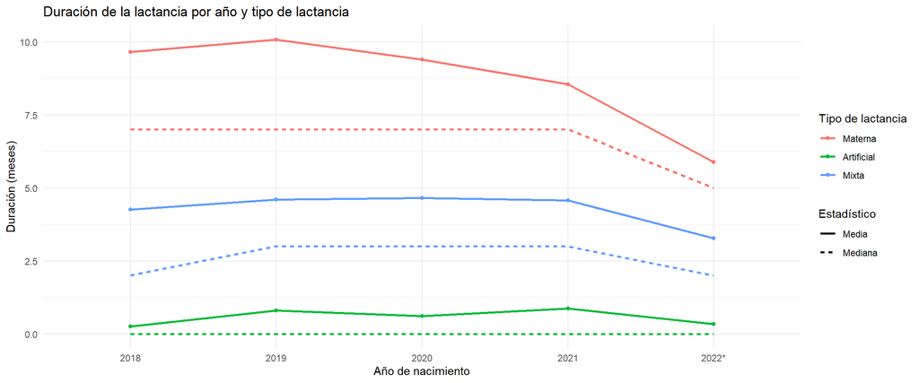

## 5.5 Evolución temporal de casos hospitalizados

Estudiamos el porcentaje de casos hospitalizados por año. A modo exploratorio, incluimos los nacidos en 2022 en los primeros gráficos de tendencias.

Numero de nacimientos y porcentajde de casos hospitalizados por infecciones por año

| Año de nacimiento | Nacimientos | Hospitalizaciones (%) |
| --- | --- | --- |
| 2018 | 12259 | 5.37 % |
| 2019 | 11809 | 4.42 % |
| 2020 | 10855 | 1.70 % |
| 2021 | 10869 | 4.67 % |
| 2022* | 10914 | 3.44 % |

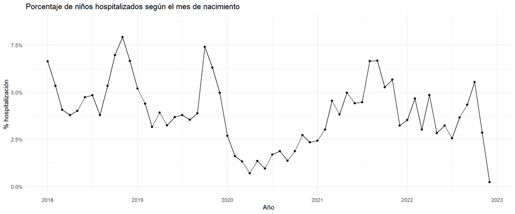

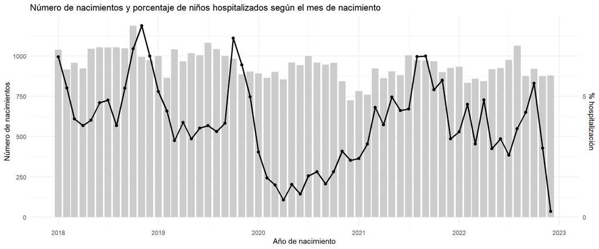

A partir de aquí no usamos la cohorte de 2022.

```
 Casos con lactancia materna informada: 11381
 Casos con lactancia materna = 0 días: 1142
 - Porcentaje con lactancia materna = 0 días: 10.03 %
 - Porcentaje con lactancia materna > 0 días: 89.97 %
```

```
# A tibble: 4 × 5
  tipo_lactancia n_lactancia_informada n_0_dias p_0_dias p_mayor_0_dias
  <fct>                          <int>    <int>    <dbl>          <dbl>
1 Materna                         7551       90     1.19           98.8
2 Artificial                      1147      955    83.3            16.7
3 Mixta                           2658       96     3.61           96.4
4 <NA>                              25        1     4              96
```

La tabla y el gráfico presentan la distribución acumulada de la duración de la lactancia materna en meses. Para cada mes evaluado, se muestra el porcentaje de casos que continúan con lactancia materna más allá de ese punto temporal.

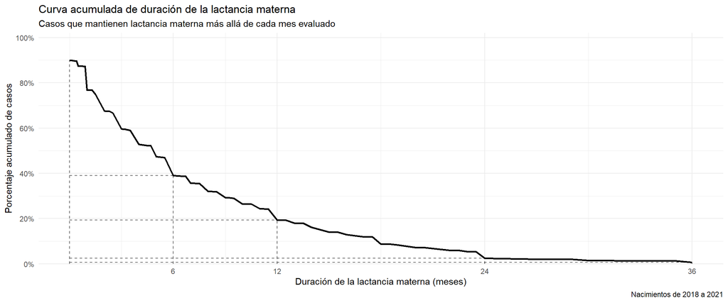

Duración acumulada de la lactancia materna

Número y porcentaje de casos que mantienen lactancia materna más allá del tiempo indicado

| Tiempo (meses) | Casos en el mes | Proporción acumulada |
| --- | --- | --- |
| 0 | 1142 | 89.97% |
| 6 | 909 | 38.95% |
| 12 | 555 | 19.37% |
| 24 | 333 | 2.48% |
| 36 | 79 | 0.62% |

Nacimientos de 2018 a 2021